# 分析交通改革的影響

108070025 簡佩如

# 1. 研究主題

分析美國紐約在提出零死亡願景計畫十年後的成效，進而分析台灣近期的交通改革。

## 1.1 摘要

台灣交通被評為危險，影響觀光發展。最近台灣修法加重汽機車不禮讓行人罰則，並恢復民眾檢舉違規行為。這份研究將透過觀察已實施改革多年的紐約，進而了解交通法規隨時間的影響力，最後回頭檢視近期台灣的交通改革是否能讓交通環境更友善。

## 1.2 key words

台灣交通交通改革、紐約交通改革、零死亡願景、禮讓行人。

## 1.3 Introduction

CNN 日前報導點出台灣交通如同行人地獄，恐不利觀光發展。其實不僅CNN這樣評論，就連瑞士外交部的旅遊建議都特別點出要注意台灣繁忙的交通，「一不小心走在斑馬線上都會身亡」。交通部統計指出2022年我國道路交通事故30日內死亡人數為3,085人，其中行人死亡事故為394人，占了約12.7%。不過最近台灣立法院會三讀通過道路交通管理處罰條例部分條文修正案，加重汽機車不禮讓行人罰則。這次修法也恢復民眾可向警政機關檢舉人行道、行人穿越道、快車道臨時停車等違規行為。根據我自身的觀察，最近走在路上確實有被汽機車禮讓的感覺。因此，這讓我很好奇這樣交通法規在未來幾年的影響力? 在查詢相關資料後我發現台灣並非第一個進行相關改革的國家，瑞典議會在1997年率先通過了「零死亡願景(Vision Zero)」，其核心精神是「任何人因為道路交通喪生或重傷，在道德上是完全無法被接受的」。在此之後世界各國如英國愛丁堡(2010年)、加拿大(2016年)、美國紐約(2014年)、澳洲(2018年)、日本(2018年)……也陸續採行，21世紀初全球的國家城市都逐漸將「盡最大的努力讓交通事故傷亡降低，朝零死亡進展」成為共同的目標。因此我希望可以透過研究已經實施相關政策好幾年的紐約，來觀察交通法規在未來幾年的影響力。

# 2. 資料前處理

```r
NYC_file_path <- "data/Motor_Vehicle_Collisions_-_Crashes.csv"
raw_NYC <- read.csv(NYC_file_path)
NYC <- raw_NYC %>%
  select( -"LOCATION",-"CRASH.TIME" , -"ZIP.CODE",-"LATITUDE",-"LONGITUDE",-"CROSS.STREET.NAME",-"OFF.STREET.NAME",-"VEHICLE.TYPE.CODE.3",-"VEHICLE.TYPE.CODE.4",-"VEHICLE.TYPE.CODE.5",-"CONTRIBUTING.FACTOR.VEHICLE.2",-"CONTRIBUTING.FACTOR.VEHICLE.3",-"CONTRIBUTING.FACTOR.VEHICLE.4",-"CONTRIBUTING.FACTOR.VEHICLE.5") %>%
  mutate(PEDESTRIANS.INJUREDANDKILLED = NUMBER.OF.PEDESTRIANS.INJURED + NUMBER.OF.PEDESTRIANS.KILLED) %>%
  mutate(CYCLIST.INJUREDANDKILLED = NUMBER.OF.CYCLIST.INJURED + NUMBER.OF.CYCLIST.KILLED) %>%
  mutate(MOTORIST.INJUREDANDKILLED = NUMBER.OF.MOTORIST.INJURED + NUMBER.OF.MOTORIST.KILLED) %>%
  filter(!is.na(NUMBER.OF.PERSONS.INJURED) & BOROUGH != "") %>%
  filter(!is.na(NUMBER.OF.PERSONS.KILLED) & BOROUGH != "")  %>%
  filter(!is.na(CRASH.DATE) & BOROUGH != "")
```

# 3. 2014年紐約「零死亡願景」

## 3.1 將時間轉成時間序列

```r
NYC <- NYC %>%
  mutate(CRASH.DATE = as.Date(CRASH.DATE, format="%m/%d/%Y")) %>%
  arrange(CRASH.DATE) %>%
  mutate(date = CRASH.DATE %>% ceiling_date("month") %>% subtract(days(1)))
```

## 3.2 Pedestrians、Cyclists 和 Motorists 的變化

```r
CRASH <- NYC %>%
  group_by(date) %>%
  summarise(
    Pedestrians = round(sum(PEDESTRIANS.INJUREDANDKILLED),3),
    Cyclists = round(sum(CYCLIST.INJUREDANDKILLED),3),
    Motorists = round(sum(MOTORIST.INJUREDANDKILLED),3),)
CRASH_data <- data.frame(
  date =  CRASH$date, Pedestrians = CRASH$Pedestrians,
  Cyclist = CRASH$Cyclists,
  Motorists = CRASH$Motorists)
CRASH_data$date <- as.Date(CRASH_data$date)
ts_CRASH_data <- ts(CRASH_data[, -1],  start = c(2012, 7), frequency = 12)
colnames(ts_CRASH_data) <- colnames(CRASH_data[, -1])
```

### 3.2.1 車禍發生數量的變化的移動平均

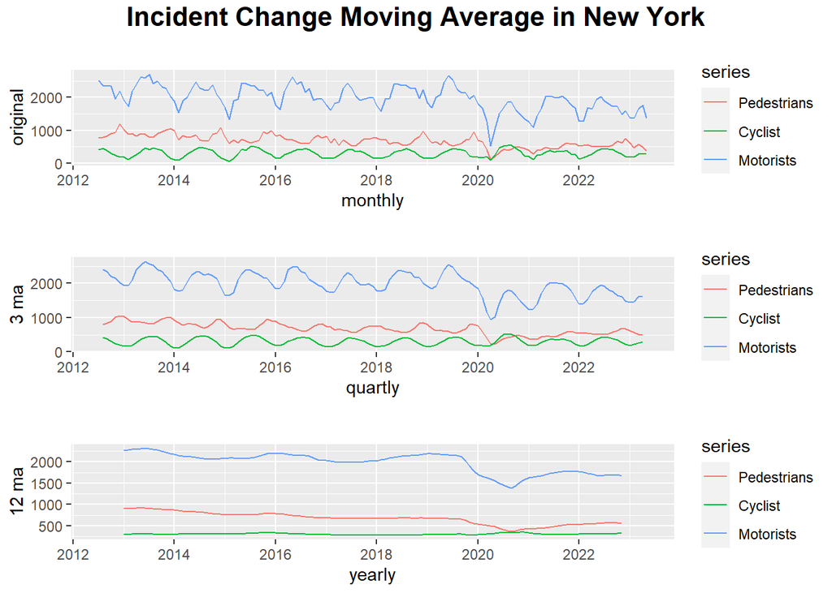

```r
ts_data <- ts_CRASH_data
a <- ma(ts_data, 3) %>%
  `colnames<-`(c("Pedestrians", "Cyclist", "Motorists")) %>%
  autoplot() +
  ylab("3 ma") +
  xlab("quartly")
b <- ma(ts_data, 12) %>%
  `colnames<-`(c("Pedestrians", "Cyclist", "Motorists")) %>%
  autoplot() +
  ylab("12 ma") +
  xlab("yearly")
d <- autoplot(ts_data) +
  ylab("original") +  # Add y-axis label
  xlab("monthly")   # Add x-axis label
grid.arrange(d, a, b, ncol = 1 , top = textGrob("Incident Change Moving Average in New York", gp = gpar(fontsize = 16, fontface = "bold")))
```

## 3.3 季節對車禍發生數量的影響

### 3.3.1 雪季和夏季的車禍分布

[figure not shown]

```r
data <- data.frame(
  date = CRASH_data$date,
  Pedestrians = CRASH_data$Pedestrians,
  Cyclists = CRASH_data$Cyclist,
  Motorists = CRASH_data$Motorists)
apr_data_june_long <- data[format(data$date, "%m") == "08", ] %>%
  pivot_longer(cols = c(Pedestrians, Cyclists, Motorists), names_to = "Category", values_to = "Count")
apr_data_january_long <- data[format(data$date, "%m") == "01", ] %>%
  pivot_longer(cols = c(Pedestrians, Cyclists, Motorists), names_to = "Category", values_to = "Count")
combined_data <- rbind(apr_data_june_long, apr_data_january_long)
ggplot(data = combined_data, aes(x = date, y = Count, color = Category)) +
  geom_jitter(size = 5, alpha = 0.7)  +
  labs(title = "Traffic Accident Variation in New York City in June and January",x = "Date",y = "Count") +
  facet_wrap(~ format(date, "%B"), ncol = 2)
```

為了驗證季節對車禍發生的影響，我比較了雪季和夏季的車禍數量。結果顯示，雖然行人在雪季的傷亡人數較高，但汽車肇事數量並未增加，反而比夏季更少。腳踏車肇事數量明顯減少，可能因為天氣冷，人們較少騎腳踏車而改為步行。這讓我想進一步分析不同季節的車禍發生數量隨時間的變化。此外，透過將每個月的車禍分為高、中和低三個等級，觀察交通法規和超速監視器計畫對車禍的總死傷人數是否有影響。希望可以藉由這些分析，能更深入了解不同季節和年份的車禍情況，以及交通安全措施的效果。

### 3.3.2 季節對車禍規模的影響

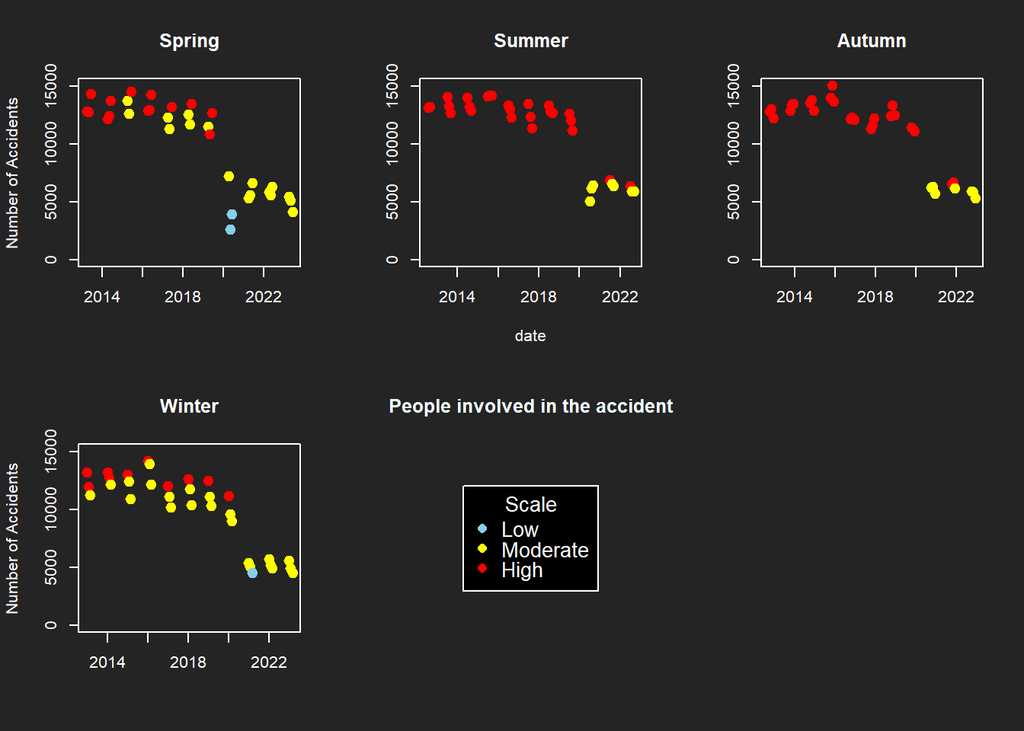

```r
NYC_scale <- NYC %>%
  group_by(date) %>%
  summarise(
    total_injured_and_killed = round(sum(PEDESTRIANS.INJUREDANDKILLED), 3)+round(sum(CYCLIST.INJUREDANDKILLED), 3)+round(sum(MOTORIST.INJUREDANDKILLED), 3),
    monthly_count = n()) %>%
  mutate(
    size = cut(total_injured_and_killed, breaks = 3, labels = c("Low", "Moderate", "High")),
    season = case_when(
      month(date) %in% c(3, 4, 5) ~ "Spring",month(date) %in% c(6, 7, 8) ~ "Summer",month(date) %in% c(9, 10, 11) ~ "Autumn", TRUE ~ "Winter"),)
par(mfrow = c(2,3),bg = "gray14", fg = "white", col.lab = "white", col.main = "white", col.axis = "white")
NYC_scale %>% filter(season == "Spring") %$%
  plot(y = monthly_count,x = date, ylim = c(0,15000),xlab ="", ylab = "Number of Accidents",pch = 20, main = "Spring",col = as.vector(recode(size,!!!dd)),cex = 2)
NYC_scale %>% filter(season == "Summer") %$%
  plot(y = monthly_count,x = date, pch = 20,ylim = c(0,15000),ylab = "",main = "Summer",col = as.vector(recode(size,!!!dd)),cex = 2)
NYC_scale %>% filter(season == "Autumn") %$%
  plot(y = monthly_count,x = date, pch = 20,ylim = c(0,15000),main = "Autumn",xlab ="", ylab = "",col = as.vector(recode(size,!!!dd)),cex = 2)
NYC_scale %>% filter(season == "Winter") %$%
  plot(y = monthly_count,x = date, pch =20,ylim = c(0,15000),main = "Winter",xlab = "",ylab = "Number of Accidents",col = as.vector(recode(size,!!!dd)),cex = 2)
par(bg = "gray14", fg = "gray14",col.lab = "gray14", col.main = "gray14", col.axis = "gray14")
NYC_scale %>% filter(season == "Winter") %$%
  plot(y = total_injured_and_killed,x = date, pch = 5)
par(bg = "black", fg = "white",col.lab = "white", col.main = "white", col.axis = "white")
legend("center", inset = c(0,0.1),pch = 16, ncol = 1,col = dd, y.intersp = 0.8,title = "Scale",legend = names(dd),cex = 1.3)
title(main = "People involved in the accident", col.main = "azure")
```

## 3.4 各行政區的分析

### 3.4.1 分析各行政區的車禍人數變化

```r
NYC_BOROUGH <- NYC %>%
  group_by(date) %>%
  summarise(
  total_injured_and_killed = round(sum(PEDESTRIANS.INJUREDANDKILLED), 3) +round(sum(CYCLIST.INJUREDANDKILLED), 3)+round(sum(MOTORIST.INJUREDANDKILLED), 3),
  BOROUGH = BOROUGH)
NYC_BOROUGH$size = NYC_BOROUGH %$% cut(total_injured_and_killed,breaks = 3,labels = c("Low", "Moderate", "High"))
NYC_BOROUGH %$% table(BOROUGH,size) %>% kable()
```

|  | Low | Moderate | High |
| --- | --- | --- | --- |
| BRONX | 2237 | 69726 | 130771 |
| BROOKLYN | 3953 | 139300 | 292324 |
| MANHATTAN | 1373 | 83255 | 225754 |
| QUEENS | 3119 | 115201 | 249993 |
| STATEN ISLAND | 450 | 16884 | 40307 |

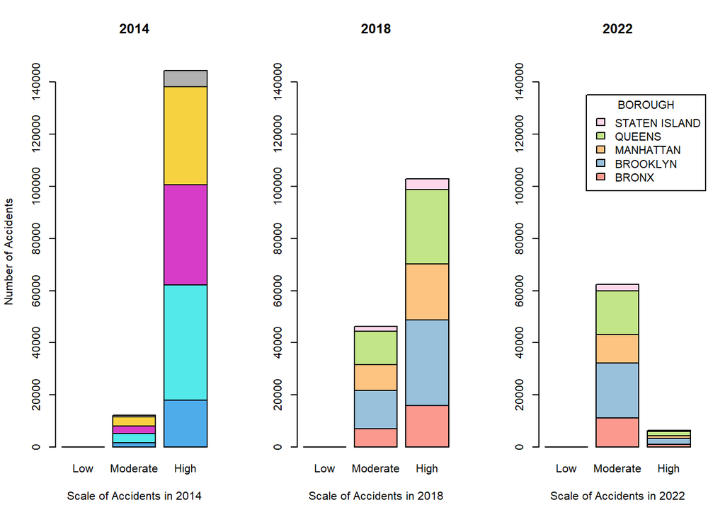

```r
par(mfrow = c(1, 3))
NYC_BOROUGH_2014 <- NYC_BOROUGH %>%
  filter(as.POSIXlt(date)$year + 1900 == 2014)
NYC_BOROUGH_2014 %$% table(BOROUGH, size) %>%
 barplot(beside = FALSE,ylim = c(0, 150000),col = palette("Set 3")[4:8] %>% alpha(0.8),main = "2014",xlab = "Scale of Accidents in 2014",ylab = "Number of Accidents")
NYC_BOROUGH_2018 <- NYC_BOROUGH %>%
  filter(as.POSIXlt(date)$year + 1900 == 2018)
NYC_BOROUGH_2018 %$% table(BOROUGH, size) %>%
  barplot(beside = FALSE,ylim = c(0, 150000),col = palette("Set 3")[4:8] %>% alpha(0.8),main = "2018", xlab = "Scale of Accidents in 2018")
NYC_BOROUGH_2022 <- NYC_BOROUGH %>%
  filter(as.POSIXlt(date)$year + 1900 == 2022)
NYC_BOROUGH_2022 %$% table(BOROUGH, size) %>%
  barplot(beside = FALSE,ylim = c(0, 150000),legend.text = rownames(.),col = palette("Set 3")[4:8] %>% alpha(0.8),
    args.legend = list(
      x = "topleft",inset = c(0.3, 0.1),title = "BOROUGH",horiz = FALSE),
    main = "2022",xlab = "Scale of Accidents in 2022")
```

從上圖中可以發現，在2014、2018和2022年間，車禍數量(Number of Accidents)和屬於死傷人數較高的類別(High)的數量明顯下降，而死傷人數次高的類別(Moderate)的數量增多。我認為除了車禍發生數量減少，每次發生車禍的死亡人數也降低。 此外，可以看到在2014年QUEENS、MANHATTAN和BROOKLYN的的死傷人數雖然一直都是前三名，但還是有明顯的下降。因此，我想繼續分析各行政區車禍死傷人數隨時間的變化。

### 3.4.2 各行政區車禍死傷人數隨時間的變化

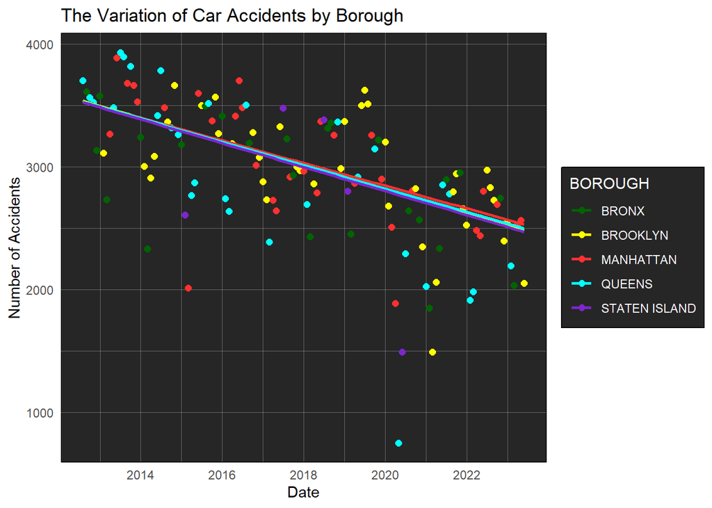

```r
NYC_BOROUGH %>%
  ggplot(aes(y = total_injured_and_killed, x = date)) +
  geom_point(aes(col = BOROUGH), size = 2) +
  geom_smooth(aes(col = BOROUGH), method = lm, se = FALSE) +
  scale_color_manual(values = c("MANHATTAN" = 'firebrick1',
                                "BROOKLYN" = 'yellow',
                                "BRONX" = 'darkgreen',
                                "QUEENS" = 'cyan',
                                "STATEN ISLAND" = 'purple3')) +
  labs(title = "The Variation of Car Accidents by Borough",
       x = "Date",
       y = "Number of Accidents") +
  theme_minimal() +
  theme(panel.background = element_rect(fill = alpha("black", 0.85)),
        panel.grid = element_line(color = alpha("white", 0.3), linewidth = 0.1),
        legend.title = element_text(color = "white"),
        legend.text = element_text(color = "white"),
        legend.box.background = element_rect(fill = alpha("black", 0.85)))
```

我將死傷人數一直都是前三名的QUEENS、MANHATTAN 和BROOKLYN標記為較亮的顏色。雖然各行政區下降的程度都差不多，但是可以看到在車禍數量前三高的行政區中，QUEENS的分布變化最多。在查詢相關資料後，發現是因為QUEENS增加的測速照相機數量最多，所以可以從途中看到淺藍色的點在2109年之後明顯下降。

### 3.4.3 各行政區的KPI

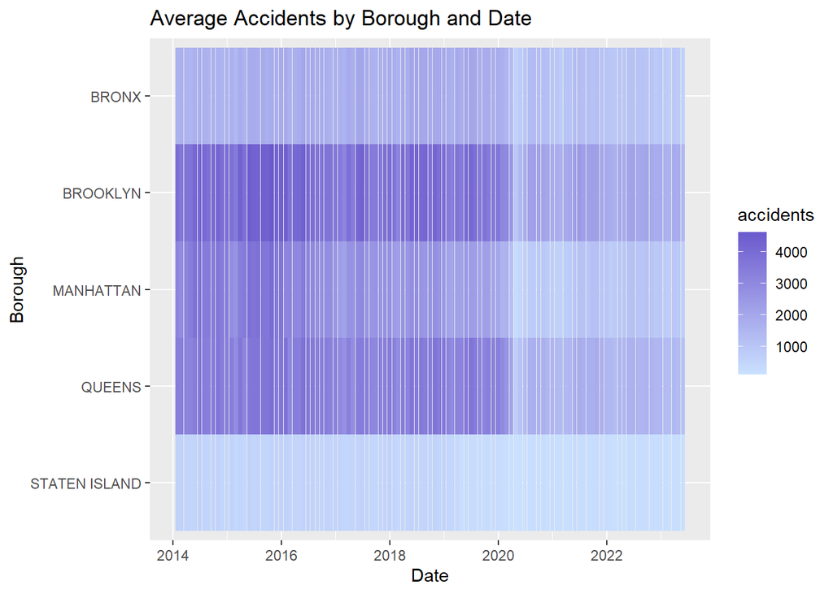

```r
NYC_BOROUGH_KPI_2 %>%
  group_by(BOROUGH, date) %>%
  summarise(accidents = mean(accidents, na.rm = TRUE)) %>%
  ggplot(aes(date, BOROUGH %>% fct_relevel(rev))) +
  geom_tile(aes(fill = accidents)) +
  geom_text(aes(label = round(accidents, 2)), color = "transparent") +
  scale_fill_gradient(low = "lightsteelblue1", high = "slateblue") +
  labs(title = "Average Accidents by Borough and Date",
       x = "Date",y = "Borough")
```

雖然說政策只有短期的效果，但是如果把每個月發生車禍的數量視覺化，還是可以發現車禍數量前三名的行政區，其車禍發生次數的變化還是相對明顯!

## 3.5 整體洞察

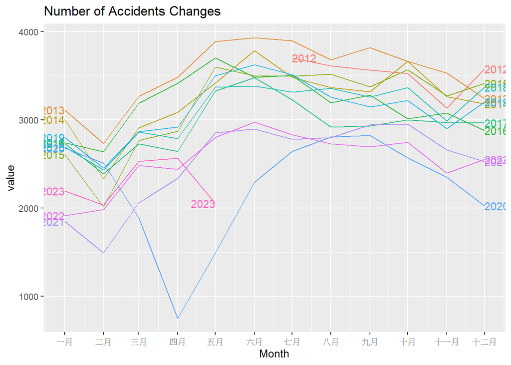

```r
df <- NYC %>%
  group_by(date) %>%
  summarise(
    total = round(sum(PEDESTRIANS.INJUREDANDKILLED), 3) +round(sum(CYCLIST.INJUREDANDKILLED), 3) +round(sum(MOTORIST.INJUREDANDKILLED), 3),)
df <- df %>%
  mutate(year_month = floor_date(date, unit = "month"))
df_summarized <- df %>%
  group_by(year_month) %>%
  summarise(across(total, sum))
df_summarized <- df_summarized %>%
  mutate(year_month = format(year_month, format = "%Y-%m"))
data_ts <- ts(df_summarized$total,start=c(2012 ,7), frequency = 12)
data_tsbl <- as_tsibble(data_ts)
data_tsbl %>%
  gg_season(value, labels = "both") +
  labs(title = "Number of Accidents Changes", x = "Month")
```

在分析紐約市的交通法規和車禍數據後，我發現儘管單個政策無法永久改善現有狀況，但在政策實施後的一段時間內，其影響力會逐漸減弱甚至失效。然而，將歷年的車禍數量進行比較，我們可以看到在當前的2023年，雖然車禍的死傷人數不是歷年最低的，但相較於政策實施之前，確實有明顯的下降。因此，我認為即使是在紐約這樣一個經過十年努力仍未實現真正”零死亡”的城市，政府的政策仍然對長期的交通狀況有所改善。因此，如果政府能夠更加靈活地提出政策，對社會將會產生正向的影響。

# 4. 2023年3月台灣的交通法規

由於我只到的到 2023年的 A1 事故，所以我將聚焦在短期內的分析。其中台灣 A1 事故的定義是造成人員當場或24小時內死亡之交通事故者，我認為這也是我們想極力避免的憾事。

## 4.1 讀取台灣車禍的資料並進行資料處理

```r
TW_file_path <- "data/A1.csv"
raw_TW <- read.csv(TW_file_path)
```

## 4.2 天氣狀況

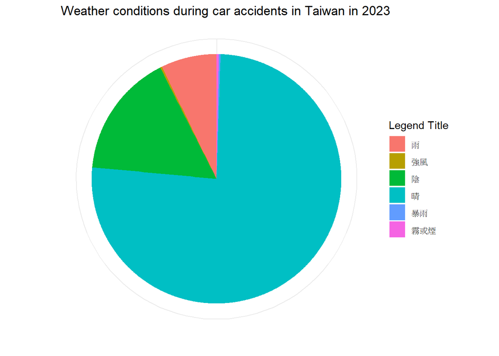

```r
ggplot(TW) +
  aes(x = "", y = "", fill = 天候名稱) +
  geom_bar(stat = "identity") +
  coord_polar(theta = "y") +
  labs(fill = "Legend Title", title = "Weather conditions during car accidents in Taiwan in 2023", x = "", y = "") +
  theme_minimal() +
  theme(axis.text = element_blank())
```

在分析紐約的車禍數量時，我注意到季節對天氣有一定的影響。由於我只擁有今年的A1交通事故數據，我分析了這些事件在不同天氣條件下的分佈情况。從圖中可以看到主要的交通事故仍然發生在晴天和陰天，這與紐約車禍中死傷人數較高的夏秋季節相符。然而，由於這裡只包含到2023年五月的數據，我認為也有可能是因為梅雨季節尚未到來，所以雨天的數據較少。

## 4.3 肇事原因分析

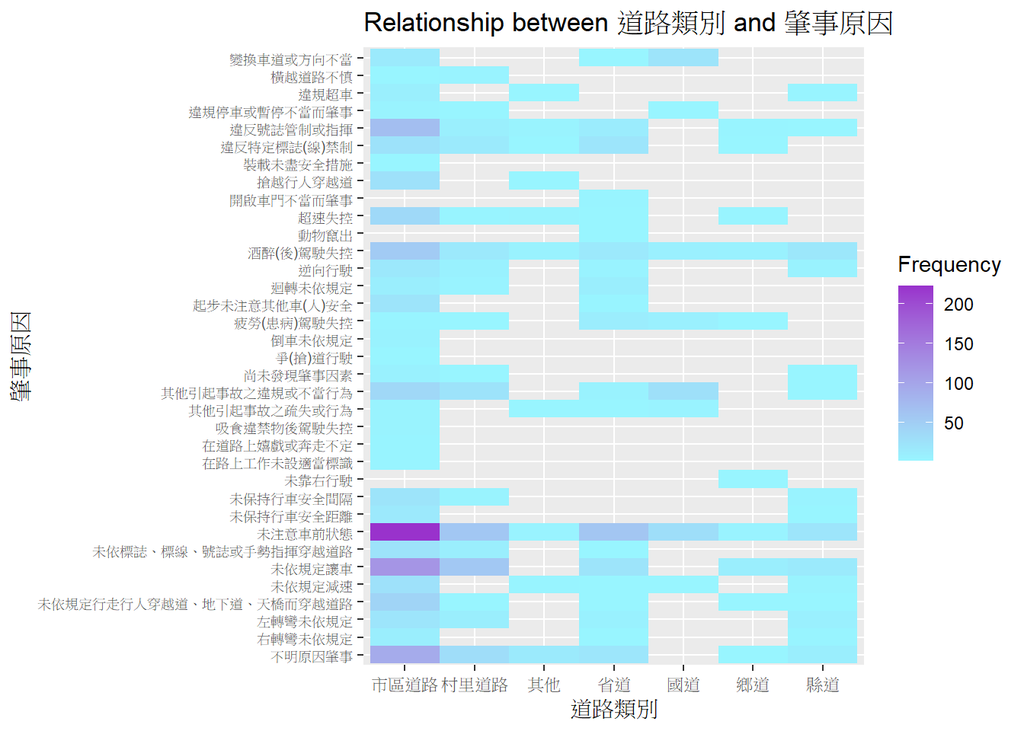

```r
cross_table <- TW %>%
  count(道路類別.第1當事者.名稱, 肇因研判子類別名稱.主要)
ggplot(cross_table, aes(x = 道路類別.第1當事者.名稱, y = 肇因研判子類別名稱.主要, fill = n)) +
  geom_tile() +
  labs(title = "Relationship between 道路類別 and 肇事原因",x = "道路類別",y = "肇事原因",fill = "Frequency") +
  scale_fill_gradient(low = "cadetblue1", high = "darkorchid") +
  theme(axis.text.y = element_text(size = 7))
```

紐約和台灣都屬於人口密集的地區，因此我選擇了紐約的交通改革作為研究對象。然而台灣有些鄉村地區路況可能與市區有所不同。因此，我比較了不同的道路類別和肇事原因。從圖中可以看出，在市區道路上發生事故的頻率較高且種類也更加多樣化，我想這表示以紐約作為台灣發展的參考是合理的。

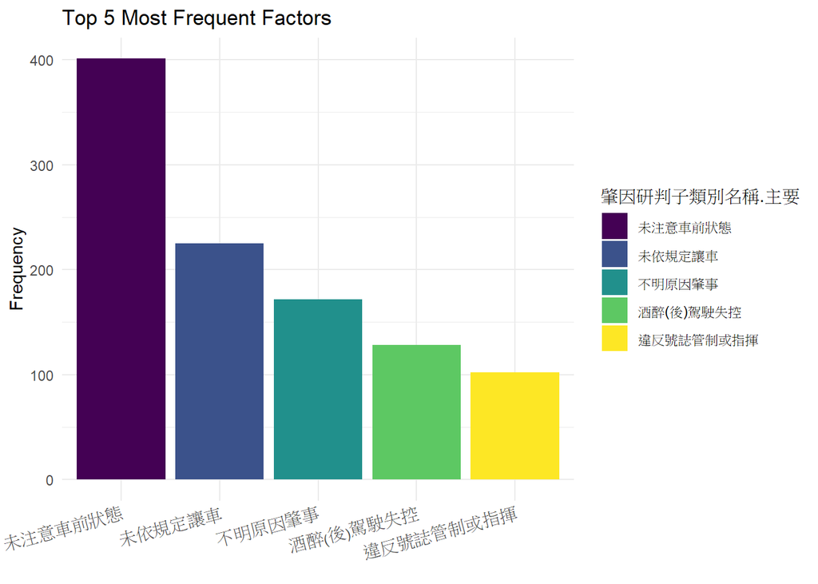

```r
top5_freq <- TW %>%
  count(肇因研判子類別名稱.主要) %>%
  arrange(desc(n)) %>%
  head(5) %>%
  mutate(肇因研判子類別名稱.主要 = factor(肇因研判子類別名稱.主要, levels = unique(肇因研判子類別名稱.主要), ordered = TRUE))
ggplot(top5_freq, aes(x = 肇因研判子類別名稱.主要, y = n, fill = 肇因研判子類別名稱.主要)) +
  geom_bar(stat = "identity") +
  labs(title = "Top 5 Most Frequent Factors") +
  xlab("") + ylab("Frequency") +theme_minimal() +theme(axis.text.x = element_text(angle = 15, hjust = 1))
```

我另外分析了前五大A1車禍的肇事原因，並發現未注意車前狀態和未依規定讓車佔據前兩名。其中台灣在2023年3月31日實施的交通法規強調了”禮讓”的概念，例如規定車輛在行經行人穿越道時應該讓行人先行通過，否則將面臨罰款1,200元至3,600元的處罰。觀察紐約市過去十年的車禍變化，可以發現2014年的交通法規和2019年的測速照相機措施主要旨在鼓勵駕駛減速慢行並禮讓行人。這些政策的實施確實降低了車禍發生數量和傷亡人數。將這些政策與台灣目前主要的車禍成因進行對照，我認為這些交通政策也有助於改善台灣的交通狀況。

## 4.5 肇事數量變化

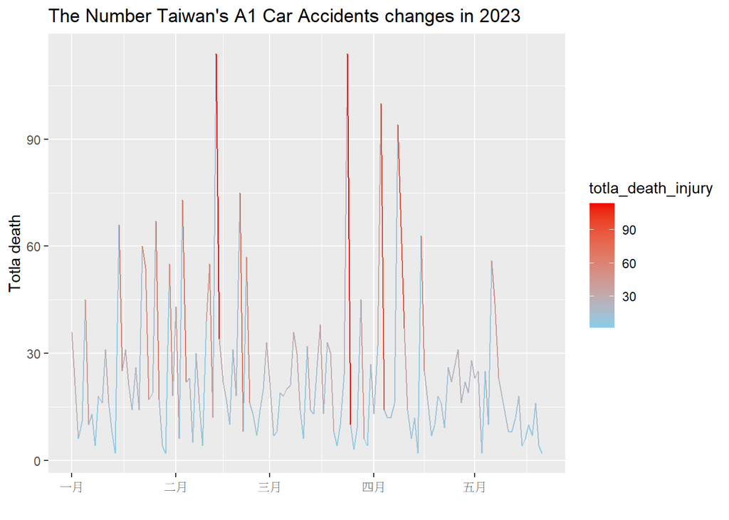

```r
CRASH <- TW %>%
  group_by(發生日期) %>%
  summarise(
    totla_death_injury = round(sum(totla_death_injury),3))
ggplot(CRASH, aes(x = 發生日期, y = totla_death_injury, color = totla_death_injury)) +
  geom_line() +
  labs(title = "The Number Taiwan's A1 Car Accidents changes in 2023",x = "", y = "Totla death") +
  scale_color_gradient(low = "skyblue", high = "red2")
```

從上面的圖表可以觀察到，在2023年3月31日台灣實施新的交通法規後，A1類型的車禍造成的死亡和傷害人數並未有顯著變化。儘管如此，我們不用氣餒，因為文化的改變需要時間，並非一朝一夕之功。我們仍然期待未來台灣的交通環境能夠逐漸改善，讓我們擺脫行人地域的惡名，創造更美好的交通氛圍!

# 5. Conclusion

在這份研究中有以下結論:

1. 紐約自2014年法規實施後，雖然行人和騎自行車者的車禍數量下降，但車禍數量有規律的波動。
2. 季節因素可能對紐約車禍的發生有影響，如冬季降雪和春季融雪。
3. 紐約各季節車禍發生數量相當，但雪季發生事故的死傷人數較少，推測這可能是因為氣候惡劣，駕駛者更加謹慎行駛。
4. 分析紐約個行政區的KPI後，發現初期實施政策可能能夠暫時降低車禍數量，但隨著時間推移，效果逐漸減弱甚至反效果。車禍數量前三名的行政區變化相對明顯。
5. 綜合分析紐約市的交通法規和車禍數據後，雖然單個政策在實施後的影響力可能會逐漸減弱，但歷年車禍數量的比較顯示在2023年，紐約市的車禍死傷人數有明顯下降。
6. 比較台灣不同的道路類別和肇事原因並發現在市區道路上發生事故的頻率較高且種類也更加多樣化，這表示以紐約作為台灣發展的參考是合理的。
7. 分析肇事原因後，台灣的交通政策可能有助於改善當前的交通狀況，只是文化的改變需要時間，所以目前還無法證實。

# 6. 3 Questions

1. Where you get your project ideas? 台灣交通法案上線後，我自己走在路上開始會被車子禮讓，這讓我很感動也增加了用路的安全感。因此想分析這樣的法規對未來的台灣可能會有甚麼影響。
2. How many new packages and functions are used?( other than those from PresTree lecture notes ) 我使用了以下套件: lubridate、magrittr、dplyr、skimr、ggplot2、forecast、gridExtra、grid、xts、feasts、forcats、knitr 和 tidyr。雖然大多是 PresTree lecture上過的，但我用到了許多時間序列的元素，像是xts，雖然上課有提到，但沒有做作業的練習。此外，比較特別的應該是forecast、gridExtra、feasts 和forcats，都是我在時間序列的做圖中用來處理資料格式以及將其視覺化的工具。
3. What is the most difficult part of your analysis? 這堂課是我第一次接觸R語言，所以對資料型態的操作不太熟，因此花最多時間在資料處理上。在課堂中練習的資料多數是整理好的，然而這次專題用到的資料都是未經整理的，所以會有很多不相關以及不能直接使用套件的變數。在所有的套件中，我花了多數的時間在處理時間序列相關的套件，因為第一次接觸到ts資料，加上它的變化非常多元，這讓我思考了很久要怎麼呈現資料。第二是資料太龐大的問題，因為十年間每天都有很多筆肇事的資料，因此數據非常龐大，除了很多噪音，也讓運算速度非常慢。不過我後來用了上課教過的yearmonth和MA等技巧解決這個問題。不管是這堂課還是這次的專題，都讓我受益良多。一開始很擔心自己沒辦法操作好R語言，但是到課堂的尾聲以及做專題的時候才驚覺更難的是創造力，也就是在有了資料跟工具後，怎麼有效率地畫出美觀且容易懂的圖。“如何讓資料變得更有意義”是我在這學期的課程中學到最珍貴的知識，也是未來可以繼續努力的方向! 最後，教授之前有說過希望大家可以提供PresTree的回饋，我覺得PresTree在我在學習R語言的過程中很受用!如果說有甚麼地方可以加強的話，我想到的是可以在點擊每個格子後，最上方可以顯示當前的路徑(像電腦檔案總管顯示路徑一樣)。 以上是我的研究報告，謝謝教授! _ _ _

# 7. Reference

1. [Motor Vehicle Collisions - Crashes](https://data.cityofnewyork.us/Public-Safety/Motor-Vehicle-Collisions-Crashes/h9gi-nx95)
2. [即時交通事故資料(A1類)](https://data.gov.tw/dataset/12818)
3. [一個都不能死：瑞典的交通「零死亡願景」](https://global.udn.com/global_vision/story/8664/6766819)
4. [台灣應該訂定「零死亡願景(Vision Zero)」](https://myway.cpami.gov.tw/Article/knowArticle/knowCont/290.html)